# Assignment_Pokemons

AMerveGezer

21 Ocak 2018

**Variables in the data** *Hashtag*: ID for each pokemon *Name*: Name of each pokemon *Type 1*: Each pokemon has a type, this determines weakness/resistance to attacks *Type 2*: Some pokemon are dual type and have 2 *Total*: sum of all stats that come after this, a general guide to how strong a pokemon is *HP*: hit points, or health, defines how much damage a pokemon can withstand before fainting *Attack*: the base modifier for normal attacks (eg. Scratch, Punch) *Defense*: the base damage resistance against normal attacks *SP Atk*: special attack, the base modifier for special attacks (e.g. fire blast, bubble beam) *SP Def*: the base damage resistance against special attacks *Speed*: determines which pokemon attacks first each round —

Source: https://www.kaggle.com/abcsds/pokemon

**2. Load and transform data**

```r
library(tidyverse)
setwd("C:/Users/merve/Desktop")

pokemon_data <- read_csv("C:/Users/merve/Desktop/Pokemon.csv")
pokemon_data
```

```
## # A tibble: 800 x 13
##      `#`                      Name `Type 1` `Type 2` Total    HP Attack
##    <int>                     <chr>    <chr>    <chr> <int> <int>  <int>
##  1     1                 Bulbasaur    Grass   Poison   318    45     49
##  2     2                   Ivysaur    Grass   Poison   405    60     62
##  3     3                  Venusaur    Grass   Poison   525    80     82
##  4     3     VenusaurMega Venusaur    Grass   Poison   625    80    100
##  5     4                Charmander     Fire     <NA>   309    39     52
##  6     5                Charmeleon     Fire     <NA>   405    58     64
##  7     6                 Charizard     Fire   Flying   534    78     84
##  8     6 CharizardMega Charizard X     Fire   Dragon   634    78    130
##  9     6 CharizardMega Charizard Y     Fire   Flying   634    78    104
## 10     7                  Squirtle    Water     <NA>   314    44     48
## # ... with 790 more rows, and 6 more variables: Defense <int>, `Sp.
## #   Atk` <int>, `Sp. Def` <int>, Speed <int>, Generation <int>,
## #   Legendary <chr>
```

```r
drop <- c("#")
pokemon_data = pokemon_data[,!(names(pokemon_data) %in% drop)]
```

**2. Data exploration**

*2.a. missing values*

```r
sapply(pokemon_data,function(x) sum(is.na(x)))
```

```
##       Name     Type 1     Type 2      Total         HP     Attack
##          0          0        386          0          0          0
##    Defense    Sp. Atk    Sp. Def      Speed Generation  Legendary
##          0          0          0          0          0          0
```

Not all pokemons have 2 types therefore, Type 2 variable has missing values.

*2.b. Do Pokemons with higher HP have lower Defense?*

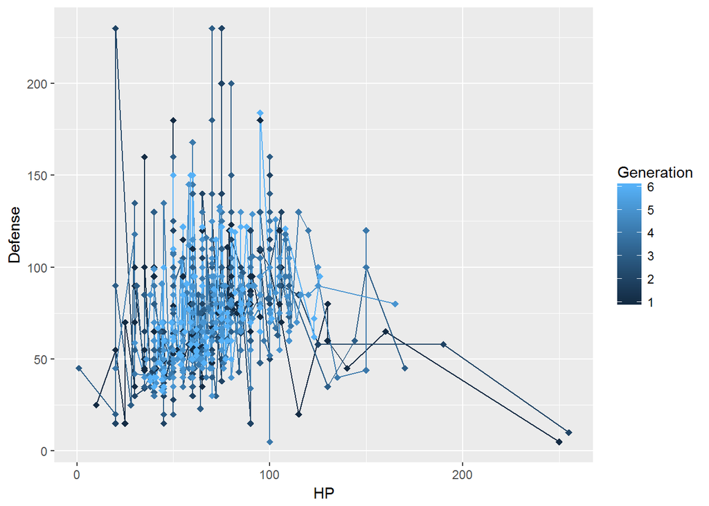

```r
pokemon_data %>%
group_by(HP) %>%
ggplot() +
aes(y=Defense, x=HP, group=Generation, color=Generation) +
geom_line (size=0.5) +
geom_point( size=2, shape=18, fill = "white")
```

Usually having higher HP means higher health, therefore these pokemons do not need as much defense power as pokemons with lower HP. This is not necesarily the case according to this data. There are in particular 2 pokemons from Generation 1 and 2 with the higest HP and have almost the lowest defense power. However the rest of the pokemons show mostly mixed HPs and defense comparisons.

*2.c. Which kind of Pokemon within Type 1 group has the highest speed?*

[figure not shown]

```r
pokemon_data %>%
  ggplot() +
  aes(x=`Type 1`, fill = Speed) +
  geom_bar() +
  labs(title = "Speed by kinds of Pokemons within Type 1 group", x ="Pokemon kinds within Type 1 group", y = "Speed")
```

**3. First hypothesis: Do Pokemons’ Attack power correlate with their Defense power**

```r
library("ggpubr")
```

*Checking distribution for attack power:*

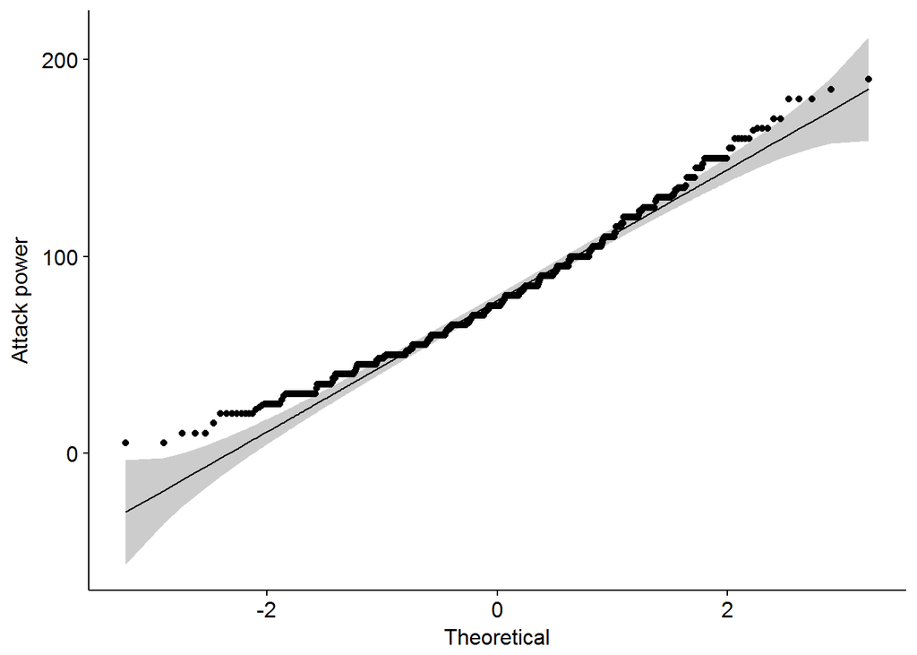

```r
ggqqplot(pokemon_data$Attack, ylab = "Attack power")
```

*Checking distribution for defense:*

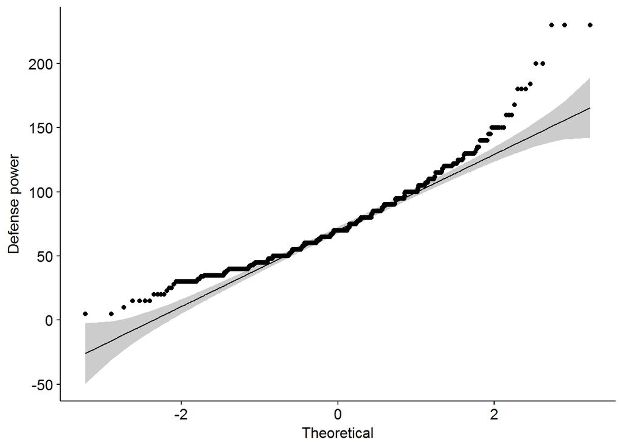

```r
ggqqplot(pokemon_data$Defense, ylab = "Defense power")
```

*Pearson’s correlation:*

```r
correlation <-cor.test(pokemon_data$Attack, pokemon_data$Defense,  method = "pearson")
correlation
```

```
##
##  Pearson's product-moment correlation
##
## data:  pokemon_data$Attack and pokemon_data$Defense
## t = 13.79, df = 798, p-value < 2.2e-16
## alternative hypothesis: true correlation is not equal to 0
## 95 percent confidence interval:
##  0.3809567 0.4930101
## sample estimates:
##       cor
## 0.4386871
```

**4. Second hypothesis: Do the generations predict Pokemons’ total power**

*Visualising with boxplot:*

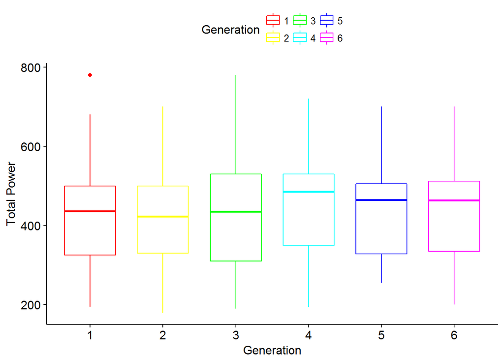

```r
library("ggpubr")

ggboxplot(pokemon_data, x = "Generation", y = "Total",
          color = "Generation", palette = c(rainbow(6)),
          order = c("1", "2", "3", "4", "5", "6"),
          ylab = "Total Power", xlab = "Generation")
```

*Anova test:*

```r
pokemon_anova <- aov(Total ~ Generation, data = pokemon_data)

summary(pokemon_anova)
```

```
##              Df   Sum Sq Mean Sq F value Pr(>F)
## Generation    1    26918   26918   1.873  0.172
## Residuals   798 11471595   14375
```

As the p-value is higher than the significance level 0.05, we can conclude that there are no significant differences between the generations and total power [F(1, 798)=1.87 p=0.172]. This means that the Pokemons do not show a statical difference in total power when compared to different generation groups.

*Check homogeneity of variances:*

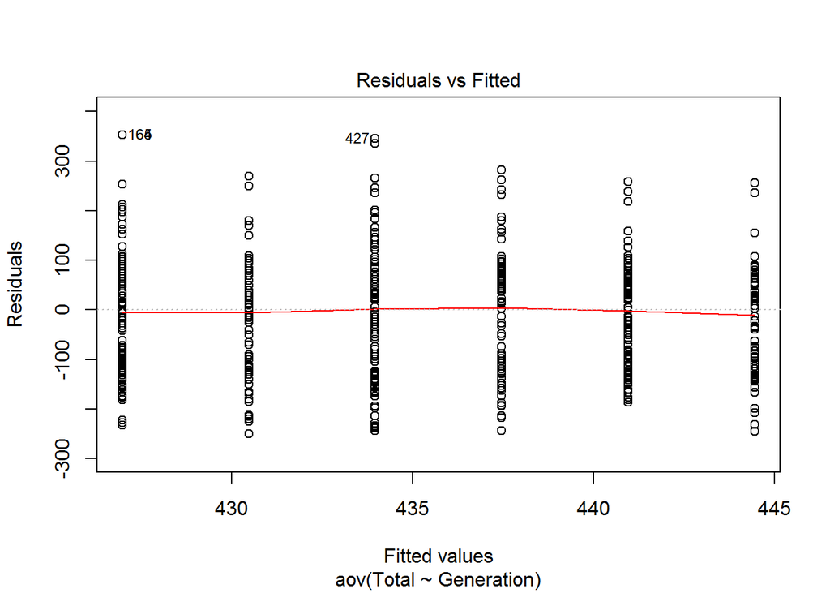

```r
plot(pokemon_anova, 1)
```

Points 165 and 427 are detected as outliers, which can affect normality and homogeneity of variance. Removing outliers can help meeting ANOVA test assumptions.

*Check normality assumption:*

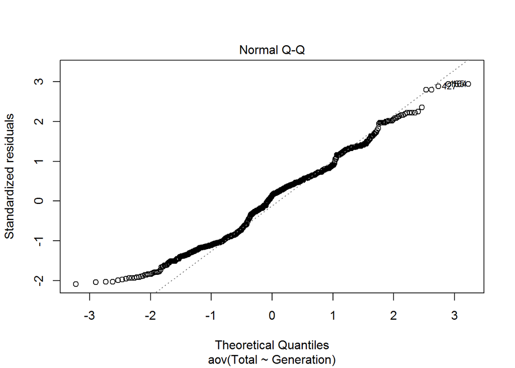

```r
plot(pokemon_anova, 2)
```

*Remove residuals:*

```r
aov_residuals <- residuals(object = pokemon_anova)
```

*Run Shapiro-Wilk test:*

```r
shapiro.test(x = aov_residuals )
```

```
##
##  Shapiro-Wilk normality test
##
## data:  aov_residuals
## W = 0.98215, p-value = 2.634e-08
```

**The End**